# 2-Filtering-Aggregation

Ethan Rogers

07/31/2026

Filtering and aggregation of peak-picked and normalized MSI data further concentrate signal and reduce noise. Additionally, these steps reduce the number of features, and therefore the number of statistical comparisons. Fewer tests mean less stringent multiple hypothesis correction and greater experimental sensitivity. Unfortunately, feature clustering is computationally intensive and may require access to high-performance computing resources.

## Load required packages and data

## Find peak-picked and normalized imzML files

```r
COMBINED_DATA_PATH <- file.path("Data","Preprocessing","normalized.imzML")
```

## Load peak-picked imzML files

We will load the combined, normalized, peak-picked image. The imzML format does not respect NA values, so Cardinal will read them as zeros when reloaded. The ROI labels (`tissue_zone`) created in `1-Preprocessing` are stored with the image and are available directly on the reloaded object.

```r
mse <- readMSIData(COMBINED_DATA_PATH, verbose = F)
```

Some features used for segmentation remain. Conducting analysis on these features is double dipping, as they have been used to create the ROIs. You can explore this concept in greater detail in `Simulation-2`. `features` will throw warnings if it can’t find a close enough m/z value. Assuming that feature was already dropped, that is OK. (Warnings are muted for this chunk.)

```r
rounded_mz_of_ROI_segmentation_ions <- c(1141.582,
                                1142.575,
                                1570.676,
                                1571.679,
                                1572.681,
                                1592.667,
                                1593.672,
                                1594.679,
                                1608.631)

indices_of_ROI_segmentation_ions <- features(mse,
                            mz = rounded_mz_of_ROI_segmentation_ions)

# If following the vignettes exactly the above step should yield two indicies
stopifnot(length(indices_of_ROI_segmentation_ions) == 2)

mse <- mse[setdiff(1:nrow(mse), indices_of_ROI_segmentation_ions), ]
```

# Non-specific filtering

We will be filtering by mean and standard deviation. We assume that noisy, non-informative features have low variation and low intensity. For simplicity, we will drop features where sample-wide mean intensity or standard deviation is in the bottom 35th percentile in non-background pixels.

Now we can compute the mean and standard deviation of each feature across all samples.

```r
mse <- subsetPixels(mse, tissue_zone != "background")
intensity(mse) <- as.matrix(intensity(mse))
mse <- summarizeFeatures(mse,
                        stat = c("mean", "sd", "nnzero"),
                        na.rm = TRUE,
                        BPPARAM = SnowfastParam(workers = 10L, force.GC = TRUE),
                        verbose = F)
```

Now we can identify features to drop.

```r
mz_to_keep <- mz(subsetFeatures(mse,
                              !(sd < quantile(sd, p = 0.35) |
                                mean < quantile(mean, p = 0.35))))
```

Let’s visualize the filter.

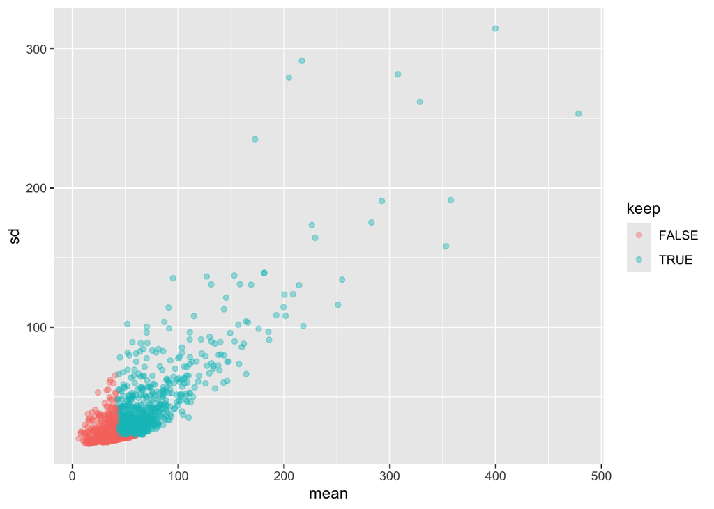

```r
as_tibble(fData(mse)) |>
  mutate(keep = !(mean < quantile(mean, p = 0.35) | sd < quantile(sd, p = 0.35))) |>
  ggplot(aes(x = mean, y = sd, color = keep)) +
  geom_point(alpha = 0.4)
```

## Apply the filter

Now apply the filter. The new MSE will have 827 features.

```r
mse <- subsetFeatures(mse, mz %in% mz_to_keep)
```

Let’s save this for later

```r
writeMSIDataSafe(mse, file.path("Data","Filtering-Aggregation","Preprocessed-NSFiltered.imzML"),
                verbose = F)
```

# Feature clustering

Clustering of related features is an active field of research with many implementations. Choosing a clustering algorithm should be done based on what you want to cluster (related molecules, spatial analogs, isotopes, adducts, precursors, etc.) and the methods to cluster (spatial similarity, kendrick mass defect, intensity ratios, etc.). As such, we treat feature clustering as an interchangeable step that takes in MSIs and returns meaningful feature clusters to the experiment.

As of version 3.6, Cardinal does not offer feature clustering methods. In this work we tested DeepION to cluster isotopes and adducts ([ACS Paper](https://doi.org/10.1021/acs.analchem.3c05002), [Github](https://github.com/gankLei-X/DeepION)), and mzClustering to cluster related spatial analogs ([Bioinformatics Paper](https://doi.org/10.1093/bioinformatics/btad067), [Original Github](https://github.com/DanGuo1223/mzClustering), [Github of install-ready version, made possible by Nihira Golasangi](https://github.com/NihiraGolasangi/mzClustering-mass-spectrometry-imaging)). At the time of publication, these methods were experimentally tested but lacked easy-to-install implementations. mzClustering has been updated by Nihira Golasangi to be install-ready from Github. DeepION may require more work to reconcile package conflicts, especially if using Apple M series chipsets. Both methods use spatial similarity to cluster features. mzClustering creates groups of similar features, while DeepION tests similarity of possible isotopes, as determined by mass differences.

Although powerful, we did not find the computational overhead of these methods to be feasible for most analyses. Additionally, neither is design for multi-sample datasets. We have instead opted to perform rudimentary clustering of C-13 isotopes using simpler methods, specifically by first identifying isotopic candidates with a known mass delta (with a mass error tolerance) then classifying candidates as isotopes by their ion image similarity. We will use pearson correlation of to assess spatial similarity and select the similary cutoff as the lowest correlation value yeilding minimal incorrect classification of random decoys pairs.

The helpers below live in `IsotopeUtilities.R`; each step is a small function so the process stays visible here. First, enumerate candidate pairs whose mass gap matches a C-13 spacing (`k = 1, 2`) within our mass tolerance. This uses no ion images, only m/z.

```r
mse_corr <- mse
X    <- as.matrix(spectra(mse_corr))
mzv  <- mz(mse_corr)
runf <- as.factor(run(mse_corr))

candidates <- find_isotope_candidates(mzv, ppm = 20, iso_spacing = 1.00335, iso_orders = 1:2)
```

Score each candidate by the spatial similarity of its two ion images. We correlate within each run and aggregate with the median, so a pair must co-localize consistently across samples. Swap `run_agg`/`pixel_mask` here to change the correlation definition.

```r
candidates$corr <- score_pairs(candidates, X, runf, run_agg = "median", pixel_mask = "all")
```

To pick a cutoff we need a null. Following MetaSpace’s target-decoy FDR, we re-pair each candidate anchor with random features at implausible mass offsets (>3 Da, so they cannot be isotopes), repeated 20 times, and score those the same way.

```r
decoys <- make_decoy_pairs(candidates, mzv, n_rep = 20, min_mz_gap = 3, seed = 1)
decoys$corr <- score_pairs(decoys, X, runf, run_agg = "median", pixel_mask = "all")
```

The cutoff is the lowest correlation at which the estimated FDR (median decoy hits / candidate hits) falls to our target. Real candidates should pile up at high correlation while decoys stay low.

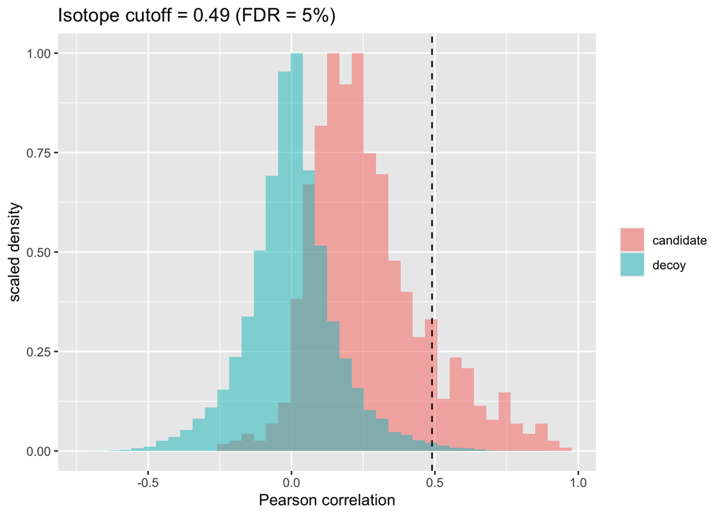

```r
fdr    <- estimate_isotope_fdr(candidates$corr, decoys$corr, decoys$rep, target_fdr = 0.05)
cutoff <- fdr$cutoff

bind_rows(
  tibble(corr = candidates$corr, set = "candidate"),
  tibble(corr = decoys$corr,     set = "decoy")
) |>
  ggplot(aes(corr, y = after_stat(ncount), fill = set)) +
  geom_histogram(alpha = 0.5, position = "identity", bins = 40, na.rm = TRUE) +
  geom_vline(xintercept = cutoff, linetype = "dashed") +
  labs(x = "Pearson correlation", y = "scaled density", fill = NULL,
       title = sprintf("Isotope cutoff = %.2f (FDR = %.0f%%)", cutoff, 100 * 0.05))
```

Keep candidate pairs above the cutoff and resolve isotope groups as connected components (so an M+0/M+1/M+2 envelope becomes one group). Every feature gets a `group_id`; unmatched features are singletons.

```r
iso_edges  <- candidates |> filter(is.finite(corr), corr > cutoff)
iso_merged <- assign_isotope_groups(iso_edges, mzv, iso_spacing = 1.00335)
```

# Feature aggregation

Isotopes are not expected to have the same abundance but are usually biologically identical. Unless experimental design requires the use of isotopes, such as experiments with C-13 labeling for quanitfication, isotopes can be aggregated without loosing any information. We will aggregate isotopes by selecting a representive ion and dropping the rest. For spatial analogs expected to be homogenous, other aggregation strategies like averaging may be more appropriate.

## Aggregate feature clusters by selecting representative features with the highest mean intensity

We will aggregate features by selecting the feature with the highest mean intensity to serve as each isotope group’s representative feature.

```r
mse_no_background_filtered <- mse |>
                              subsetPixels(tissue_zone != "background") |> #just in case
                              subsetFeatures(mz %in% iso_merged$mz) |>
                              summarizeFeatures(stat = "mean", na.rm = T)

stopifnot(all(mz(mse)==iso_merged$mz))

iso_merged$mean <- as.vector(fData(mse_no_background_filtered)$mean)
```

Now let’s drop low abundance isotopes, keeping only the feature with the highest mean in each group.

```r
#sanity check
isotopes_to_keep <- iso_merged |>
                          group_by(group_id) |>
                          filter(mean == max(mean)) |>
                          ungroup() |>
                          pull(mz)

mse <- subsetFeatures(mse, mz %in% isotopes_to_keep)
```

Save this intermediate.

```r
writeMSIDataSafe(mse, file.path("Data","Filtering-Aggregation","Preprocessed-NSFiltered-Aggregated.imzML"),
                verbose = F)
```

Like during initial peak picking, we will apply a filter that will save us a lot of trouble later during statistical modeling. Highly sparse features create unstable estimates of mean abundance. The models detailed in this work assume normal distributions of residuals. Zero inflation will cause serious deviation from this assumption, yielding poor fit and invalid results. To keep things simple, we will drop features that are very sparse in the cartilage ROI. This represents a conservative modeling approach and will drastically reduce the number of features we continue analysis with. Alternate options include using models that are invariant to zero inflation.

Drop features that are present (non-zero and finite) in fewer than 50% of pixels in any run.

```r
mse_cartilage <- subsetPixels(mse, tissue_zone== "cartilage")

mse_cartilage <- summarizeFeatures(mse_cartilage,
                                  stat = c("mean", "sd", "nnzero"),
                                  na.rm = TRUE,
                                  groups = mse_cartilage$run,
                                  verbose = F)

mse_cartilage_filt <- filterFeaturesByRunFreq(mse_cartilage, 0.5)

mse <- subsetFeatures(mse, mz %in% mz(mse_cartilage_filt))
```

Save the as .imzML files. Onward to modeling!

```r
writeMSIDataSafe(mse, file.path("Data","Filtering-Aggregation","Preprocessed-NSFiltered-Aggregated-CartilageFiltered50.imzML"),
                verbose = F)
```

### Code to recreate figures and tables

```r
mse_pp <- readMSIData(file.path("Data", "Preprocessing", "Recalibrated-Picked-Aligned-FreqFiltered05perRun.imzML"),
  verbose = F)
mse_pre_filt <- readMSIData(COMBINED_DATA_PATH)
mse_ns_filt <- readMSIData(file.path("Data","Filtering-Aggregation","Preprocessed-NSFiltered.imzML"),
  verbose = F)
mse_deiso <- readMSIData(file.path("Data","Filtering-Aggregation","Preprocessed-NSFiltered-Aggregated.imzML"),
  verbose = F)
mse_cart_filtered <- readMSIData(file.path("Data","Filtering-Aggregation","Preprocessed-NSFiltered-Aggregated-CartilageFiltered50.imzML"),
  verbose = F)

# Count feature drops dynamically at each stage, so the narrative stays correct
# regardless of how many ions each step removes.
n_pp    <- length(mz(mse_pp))
n_norm  <- length(mz(mse_pre_filt))
n_ns    <- length(mz(mse_ns_filt))
n_deiso <- length(mz(mse_deiso))
n_cart  <- length(mz(mse_cart_filtered))

# ROI-selection ions still present in the normalized image that are dropped in this vignette
n_roi_dropped <- length(indices_of_ROI_segmentation_ions)
n_pre_ns <- n_norm - n_roi_dropped  # after dropping ROI ions, before NS filtering

cat("After Peak Picking ", n_pp, "\n")
```

```
## After Peak Picking  1619
```

```r
cat("After dropping internal standard ions [-", n_pp - n_norm, "] ", n_norm, "\n", sep = "")
```

```
## After dropping internal standard ions [-7] 1612
```

```r
cat("After dropping other ions used in ROI selection [-", n_roi_dropped,
  "] and before NS filtering ", n_pre_ns, "\n", sep = "")
```

```
## After dropping other ions used in ROI selection [-2] and before NS filtering 1610
```

```r
cat("After NS filtering [-", n_pre_ns - n_ns, "] ", n_ns, "\n", sep = "")
```

```
## After NS filtering [-783] 827
```

```r
cat("After deiso [-", n_ns - n_deiso, "] ", n_deiso, "\n", sep = "")
```

```
## After deiso [-115] 712
```

```r
cat("After cartilage sparsity filtering [-", n_deiso - n_cart, "] ", n_cart, "\n", sep = "")
```

```
## After cartilage sparsity filtering [-90] 622
```

```r
cat("Table S3\n")
```

```
## Table S3
```

```r
cat("Approximate m/z of preselected features used to segment cartilage (and isotopes/spatial analogs): ",
  paste(round(c(1141.582, 1142.575),3), collapse = ", "), "\n")
```

```
## Approximate m/z of preselected features used to segment cartilage (and isotopes/spatial analogs):  1141.582, 1142.575
```

```r
cat("Approximate m/z of preselected features used to segment background (and isotopes/spatial analogs): ",
  paste(round(c(1570.676, 1571.679, 1572.681, 1592.667, 1593.672, 1594.679, 1608.631),3), collapse = ", "), "\n")
```

```
## Approximate m/z of preselected features used to segment background (and isotopes/spatial analogs):  1570.676, 1571.679, 1572.681, 1592.667, 1593.672, 1594.679, 1608.631
```

```r
cat("Approximate m/z of features removed by non-specific filtering: ",
  paste(setdiff(round(setdiff(mz(mse_pre_filt), mz(mse_ns_filt)),3), round(rounded_mz_of_ROI_segmentation_ions, 3)), collapse = ", "), "\n")
```

```
## Approximate m/z of features removed by non-specific filtering:  1041.48, 1056.549, 1057.548, 1069.506, 1072.518, 1079.497, 1090.482, 1096.489, 1097.513, 1098.509, 1099.507, 1106.464, 1107.47, 1117.53, 1118.544, 1119.483, 1120.49, 1120.574, 1121.485, 1121.572, 1122.487, 1123.484, 1123.559, 1131.52…
```

```r
cat("Table S4\n")
```

```
## Table S4
```

```r
cat("Approximate single ion m/z features: ",
  paste(round(iso_merged |> group_by(group_id) |> filter(n() == 1) |> pull(mz),3), collapse = ", "), "\n")
```

```
## Approximate single ion m/z features:  897.442, 1040.475, 1041.543, 1068.504, 1110.559, 1118.472, 1122.557, 1125.53, 1143.583, 1163.494, 1164.491, 1171.532, 1179.541, 1180.535, 1181.534, 1203.509, 1203.576, 1204.545, 1205.561, 1222.538, 1233.565, 1285.601, 1286.629, 1299.577, 1302.584, 1305.566, 1…
```

```r
cat("Approximate m/z features part of 2-member isotope groups: ",
  paste(round(iso_merged |> group_by(group_id) |> filter(n() == 2) |> pull(mz),3), collapse = ", "), "\n")
```

```
## Approximate m/z features part of 2-member isotope groups:  1034.573, 1035.575, 1115.54, 1116.534, 1126.52, 1127.521, 1128.517, 1129.517, 1137.523, 1138.516, 1156.522, 1157.519, 1172.524, 1173.524, 1211.613, 1212.616, 1248.55, 1249.558, 1257.578, 1258.578, 1283.587, 1283.637, 1284.59, 1284.637, 13…
```

```r
cat("Approximate m/z features part of 3-member isotope groups: ",
  paste(round(iso_merged |> group_by(group_id) |> filter(n() == 3) |> pull(mz),3), collapse = ", "), "\n")
```

```
## Approximate m/z features part of 3-member isotope groups:  1141.52, 1142.512, 1143.517, 1242.577, 1243.574, 1244.57, 1302.655, 1303.651, 1304.635, 1343.67, 1344.672, 1345.675, 1406.712, 1407.718, 1408.719, 1426.662, 1427.66, 1428.668, 1483.719, 1484.724, 1485.727, 1495.702, 1496.715, 1497.697, 15…
```

```r
cat("Approximate m/z features part of 4-member or more isotope groups: ",
  paste(round(iso_merged |> group_by(group_id) |> filter(n() >= 4) |> pull(mz),3), collapse = ", "), "\n")
```

```
## Approximate m/z features part of 4-member or more isotope groups:  1366.651, 1367.634, 1368.631, 1369.62, 1446.655, 1447.657, 1448.647, 1449.644, 1508.726, 1509.719, 1510.696, 1511.692, 1787.779, 1788.784, 1789.796, 1790.791, 1791.775, 1880.85, 1881.848, 1882.855, 1883.85, 1916.83, 1918.844, 1919…
```

```r
cat("Approximate m/z features dropped during Cartilage ROI sparsity filtering: ",
  paste(round(setdiff(mz(mse_deiso), mz(mse_cart_filtered)),3), collapse = ", "), "\n")
```

```
## Approximate m/z features dropped during Cartilage ROI sparsity filtering:  1034.573, 1041.543, 1122.557, 1143.583, 1203.576, 1211.613, 1286.629, 1302.584, 1305.566, 1381.711, 1382.706, 1386.683, 1397.698, 1398.697, 1406.712, 1408.628, 1437.636, 1438.772, 1459.623, 1480.663, 1480.762, 1481.658, 14…
```

```r
knitr::kable(
  iso_merged |>
    group_by(group_id) |>
    mutate(`Isotopes in a group` = n()) |>
    ungroup() |>
    group_by(`Isotopes in a group`) |>
    summarize(
      `Count of ions`   = n(),
      `Count of groups` = n_distinct(group_id),
      .groups = "drop"
    )
)
```

| Isotopes in a group | Count of ions | Count of groups |
| --- | --- | --- |
| 1 | 641 | 641 |
| 2 | 78 | 39 |
| 3 | 69 | 23 |
| 4 | 24 | 6 |
| 5 | 15 | 3 |

```r
m <- mse_pre_filt |>
    subsetFeatures(mz %in% mz(mse_ns_filt)) |>
    subsetPixels(mse_pre_filt$run == "6891-OA-lateral")

jl_3 <- sort(unique(iso_merged |> group_by(group_id) |>
  mutate(n = n()) |> ungroup() |> filter(n == 3) |> pull(group_id)))

#all
image_png(m, i = iso_merged |> filter(group_id %in% jl_3) |> pull(feature_id), scale = T,
style = "dark", bg="black", key = F, grid = F, pointsize = 36, superpose = F, filename="tmp/all_3mbisos.png",
      width = 1500,
      height = 100 + (300 * length(jl_3)),
      layout = c(length(jl_3),3),
      xaxt = "n",
      yaxt = "n",
      ylab = NA,
      xlab = NA)


# groups are picked by monoisotopic m/z
id_1 <- iso_merged |> filter(group_id %in% jl_3, round(monoisotopic_mz, 3) == 1781.899) |> pull(feature_id)
id_2 <- iso_merged |> filter(group_id %in% jl_3, round(monoisotopic_mz, 3) == 1923.868) |> pull(feature_id)
id_3 <- iso_merged |> filter(group_id %in% jl_3, round(monoisotopic_mz, 3) == 2501.243) |> pull(feature_id)
stopifnot(lengths(list(id_1, id_2, id_3)) == 3)

fig_i <- c(id_1[1], id_2[1], id_3[1], id_1[2], id_2[2], id_3[2],id_1[3], id_2[3], id_3[3])
names(fig_i) <- sprintf("m/z = %.3f", mz(m)[fig_i])

png(filename = file.path("Recreated-Figures","Figure-clusters-3-isotope-sii.png"), width = 1500, height = 900, pointsize = 54)
image(m, i = fig_i,
      scale = T,
      superpose = F,
      layout = c(3,3),
      key = F,
      grid = F,
      xaxt = "n",
      yaxt = "n",
      ylab = NA,
      xlab = NA)
dev.off()
```

```r
#########
jl <- sort(unique(iso_merged |> group_by(group_id) |> mutate(n = n()) |> ungroup() |> filter(n == 2) |> pull(group_id)))

#all
#image_png(m, i = iso_merged |> filter(group_id %in% jl) |> pull(feature_id), scale = T,
#style = "dark", bg="black", key = F, grid = F, pointsize = 36, superpose = F, filename="tmp/all_2mbisos.png",
#      width = 1500,
#      height = 100 + (300 * length(jl)),
#      layout = c(length(jl),2),
#      xaxt = "n",
#      yaxt = "n",
#      ylab = NA,
#      xlab = NA)

# groups are picked by monoisotopic m/z
id_1 <- iso_merged |> filter(group_id %in% jl, round(monoisotopic_mz, 3) == 1128.517) |> pull(feature_id)
id_2 <- iso_merged |> filter(group_id %in% jl, round(monoisotopic_mz, 3) == 2135.954) |> pull(feature_id)
id_3 <- iso_merged |> filter(group_id %in% jl, round(monoisotopic_mz, 3) == 2231.128) |> pull(feature_id)
stopifnot(lengths(list(id_1, id_2, id_3)) == 2)

fig_i <- c(id_1[1], id_2[1], id_3[1], id_1[2], id_2[2], id_3[2])
names(fig_i) <- sprintf("m/z = %.3f", mz(m)[fig_i])

png(filename = file.path("Recreated-Figures","Figure-clusters-2-isotope-sii.png"), width = 1500, height = 700, pointsize = 54)
image(m, i = fig_i,
      scale = T,
      superpose = F,
      layout = c(2,3),
      key = F,
      grid = F,
      xaxt = "n",
      yaxt = "n",
      ylab = NA,
      xlab = NA)
dev.off()
```

```r
paste0(iso_merged |>
         group_by(group_id) |>
         mutate(n = n()) |>
         ungroup() |> filter(n == 1) |> mutate(mzr = round(mz, 4)) |> pull(mzr),
       collapse = ", ")
```

```
## [1] "897.4416, 1040.475, 1041.5426, 1068.5039, 1110.5592, 1118.4718, 1122.5575, 1125.5299, 1143.5827, 1163.4943, 1164.4913, 1171.5321, 1179.5411, 1180.5354, 1181.5335, 1203.5092, 1203.5764, 1204.5446, 1205.5612, 1222.5382, 1233.5655, 1285.6011, 1286.6294, 1299.5767, 1302.5842, 1305.5659, 1305.638…
```

```r
paste0(iso_merged |>
         group_by(group_id) |>
         mutate(n = n()) |>
         ungroup() |> filter(n == 2) |> mutate(mzr = round(mz, 4)) |> pull(mzr),
       collapse = ", ")
```

```
## [1] "1034.5727, 1035.5755, 1115.5397, 1116.534, 1126.5201, 1127.5209, 1128.517, 1129.5165, 1137.5229, 1138.5156, 1156.5223, 1157.5189, 1172.5242, 1173.5237, 1211.6135, 1212.6157, 1248.5504, 1249.5578, 1257.5776, 1258.5779, 1283.5867, 1283.6368, 1284.5903, 1284.6372, 1386.6834, 1387.6929, 1399.637…
```

```r
paste0(iso_merged |>
         group_by(group_id) |>
         mutate(n = n()) |>
         ungroup() |> filter(n == 3) |> mutate(mzr = round(mz, 4)) |> pull(mzr),
       collapse = ", ")
```

```
## [1] "1141.5204, 1142.5117, 1143.5166, 1242.5774, 1243.5743, 1244.5704, 1302.6547, 1303.6509, 1304.6346, 1343.6699, 1344.6723, 1345.6748, 1406.7123, 1407.718, 1408.7194, 1426.6618, 1427.6604, 1428.6685, 1483.7195, 1484.7241, 1485.7267, 1495.7021, 1496.7146, 1497.6975, 1595.7571, 1596.7529, 1597.75…
```

```r
paste0(iso_merged |>
         group_by(group_id) |>
         mutate(n = n()) |>
         ungroup() |> filter(n >= 4) |> mutate(mzr = round(mz, 4)) |> pull(mzr),
       collapse = ", ")
```

```
## [1] "1366.6512, 1367.6342, 1368.631, 1369.6201, 1446.6552, 1447.6569, 1448.6474, 1449.644, 1508.7259, 1509.7187, 1510.6961, 1511.6916, 1787.7792, 1788.7843, 1789.7956, 1790.7908, 1791.7754, 1880.8502, 1881.8478, 1882.8548, 1883.85, 1916.8303, 1918.8443, 1919.845, 1920.8504, 2096.9983, 2097.9995, …
```